# Netflix_EDA_project1_1762381293

Author Name: Sathish Kupendra

#### Business context

This dataset of Netflix Movies and TV Shows gives a complete catalog of possible Netflix offerings with details including titles, types (Movies or TV Shows), countries of origin, release year, ratings, durations, genres, and descriptions. The dataset offers useful data into the content library of Netflix so that a stakeholder may be able to invest and develop contents, together with deciding appropriate means to engage the audience.

#### Objective

The main goal is to analyze the Netflix dataset:

The Objective here is to perform exploratory data analysis, Using the attributes like title, country, date added, release year, rating, duration, and listed genres, this research project helps us to complete the task of analyzing Netflix's collection of films and TV series. The information about the content availability by region, popular genres, regional diversity, audience targeting through ratings, and release time trends, would all be sought after by this analysis. By providing answers to important business questions, this study will enable the stakeholders to take a well informed choices and decisions regarding the audience engagement tactics, content investments, and market expansion prospects.

#### Data Source

The Dataset is from Kaggle and the link for the dataset: https://www.kaggle.com/datasets/rahulvyasm/netflix-movies-and-tv-shows

#### Business Questions

1. How is the platforms content divided between Movies and TV Shows, and how has that changed over the years?
2. Which countries produce the highest volume of content, and does the nature of such content differ from one country to another?
3. Does any certain months or seasons show higher numbers of content additions on the platform?
4. Is there a correlation between content duration, rating, and the year of release? For example, do longer movies or shows tend to have higher ratings or be produced more recently?
5. What genres stand out as the most popular, and how common is it for a show or a movie to be classified under several genres?

#### Data Exploration

##### Data Cleaning

Importing required library

```python
import pandas as pd
import numpy as np
import matplotlib.pyplot as plt
import seaborn as sns
from datetime import datetime
import plotly.express as px
```

```python
pd.set_option('display.max_columns', None)
#pd.set_option('display.max_rows', None)
```

```python
dataFrame = pd.read_csv("/content/drive/MyDrive/Me/Class/AI/Project dataset/netflix_titles.csv", encoding='latin1')
```

Creating a copy of the dataset

```python
df = dataFrame.copy()
```

Viewing the first 5 rows from the dataset and reading the number of rows and column

```python
display(df.head())
display(df.shape)
```

|  | show_id | type | title | director | cast | country | date_added | release_year | rating | duration | listed_in | description | Unnamed: 12 | Unnamed: 13 | Unnamed: 14 | Unnamed: 15 | Unnamed: 16 | Unnamed: 17 | Unnamed: 18 | Unnamed: 19 | Unnamed: 20 | Unnamed: 21 | Unnamed: 22 | Unnamed: 23 | Unnamed: 24 | Unnamed: 25 |
| --- | --- | --- | --- | --- | --- | --- | --- | --- | --- | --- | --- | --- | --- | --- | --- | --- | --- | --- | --- | --- | --- | --- | --- | --- | --- | --- |
| 0 | s1 | Movie | Dick Johnson Is Dead | Kirsten Johnson | NaN | United States | September 25, 2021 | 2020 | PG-13 | 90 min | Documentaries | As her father nears the end of his life, filmm... | NaN | NaN | NaN | NaN | NaN | NaN | NaN | NaN | NaN | NaN | NaN | NaN | NaN | NaN |
| 1 | s2 | TV Show | Blood & Water | NaN | Ama Qamata, Khosi Ngema, Gail Mabalane, Thaban... | South Africa | September 24, 2021 | 2021 | TV-MA | 2 Seasons | International TV Shows, TV Dramas, TV Mysteries | After crossing paths at a party, a Cape Town t... | NaN | NaN | NaN | NaN | NaN | NaN | NaN | NaN | NaN | NaN | NaN | NaN | NaN | NaN |
| 2 | s3 | TV Show | Ganglands | Julien Leclercq | Sami Bouajila, Tracy Gotoas, Samuel Jouy, Nabi... | NaN | September 24, 2021 | 2021 | TV-MA | 1 Season | Crime TV Shows, International TV Shows, TV Act... | To protect his family from a powerful drug lor... | NaN | NaN | NaN | NaN | NaN | NaN | NaN | NaN | NaN | NaN | NaN | NaN | NaN | NaN |
| 3 | s4 | TV Show | Jailbirds New Orleans | NaN | NaN | NaN | September 24, 2021 | 2021 | TV-MA | 1 Season | Docuseries, Reality TV | Feuds, flirtations and toilet talk go down amo... | NaN | NaN | NaN | NaN | NaN | NaN | NaN | NaN | NaN | NaN | NaN | NaN | NaN | NaN |
| 4 | s5 | TV Show | Kota Factory | NaN | Mayur More, Jitendra Kumar, Ranjan Raj, Alam K... | India | September 24, 2021 | 2021 | TV-MA | 2 Seasons | International TV Shows, Romantic TV Shows, TV ... | In a city of coaching centers known to train I... | NaN | NaN | NaN | NaN | NaN | NaN | NaN | NaN | NaN | NaN | NaN | NaN | NaN | NaN |

```
(8809, 26)
```

In our dataset, we have **8809 rows** and **26 columns.** But these columns **['Unnamed: 12', 'Unnamed: 13', 'Unnamed: 14', 'Unnamed: 15', 'Unnamed: 16', 'Unnamed: 17', 'Unnamed: 18', 'Unnamed: 19', 'Unnamed: 20', 'Unnamed: 21', 'Unnamed: 22', 'Unnamed: 23', 'Unnamed: 24', 'Unnamed: 25']** does'nt have any values. so we are going drop these columns as it's not useful for the analysis.

```python
# Dropping the Unnamed columns
unnamed_cols = [col for col in dataFrame.columns if col.startswith('Unnamed')]
df.drop(columns=unnamed_cols, inplace=True)
```

```python
# Viewing the data after dropping unnamed columns
df.head()
```

|  | show_id | type | title | director | cast | country | date_added | release_year | rating | duration | listed_in | description |
| --- | --- | --- | --- | --- | --- | --- | --- | --- | --- | --- | --- | --- |
| 0 | s1 | Movie | Dick Johnson Is Dead | Kirsten Johnson | NaN | United States | September 25, 2021 | 2020 | PG-13 | 90 min | Documentaries | As her father nears the end of his life, filmm... |
| 1 | s2 | TV Show | Blood & Water | NaN | Ama Qamata, Khosi Ngema, Gail Mabalane, Thaban... | South Africa | September 24, 2021 | 2021 | TV-MA | 2 Seasons | International TV Shows, TV Dramas, TV Mysteries | After crossing paths at a party, a Cape Town t... |
| 2 | s3 | TV Show | Ganglands | Julien Leclercq | Sami Bouajila, Tracy Gotoas, Samuel Jouy, Nabi... | NaN | September 24, 2021 | 2021 | TV-MA | 1 Season | Crime TV Shows, International TV Shows, TV Act... | To protect his family from a powerful drug lor... |
| 3 | s4 | TV Show | Jailbirds New Orleans | NaN | NaN | NaN | September 24, 2021 | 2021 | TV-MA | 1 Season | Docuseries, Reality TV | Feuds, flirtations and toilet talk go down amo... |
| 4 | s5 | TV Show | Kota Factory | NaN | Mayur More, Jitendra Kumar, Ranjan Raj, Alam K... | India | September 24, 2021 | 2021 | TV-MA | 2 Seasons | International TV Shows, Romantic TV Shows, TV ... | In a city of coaching centers known to train I... |

```python
# Checking the columns
list(df.columns)
```

```
['show_id',
 'type',
 'title',
 'director',
 'cast',
 'country',
 'date_added',
 'release_year',
 'rating',
 'duration',
 'listed_in',
 'description']
```

We can see that we have successfully removed the unnamed columns from the dataset. But these columns [**show_id, director, cast, description**] there are some columns which are not useful for the analysis. so we will be removing it.

```python
cols_to_drop = ['show_id', 'director', 'cast', 'description']
existing_cols = [col for col in cols_to_drop if col in df.columns]
df.drop(columns=existing_cols, inplace=True)
```

Checking for the null values

```python
df.isnull().sum()
```

|  | 0 |
| --- | --- |
| type | 0 |
| title | 0 |
| country | 831 |
| date_added | 10 |
| release_year | 0 |
| rating | 4 |
| duration | 3 |
| listed_in | 0 |

**dtype:** int64

We can see that there are null values in **[country, date_added, rating, duration]** in the dataset. Among these columns **country** has highest number of missing values.

```python
#Calculating percentage of missing values
missing_percentage = round((df.isnull().sum() / len(df)) * 100, 2)
print(missing_percentage)
```

```
type            0.00
title           0.00
country         9.43
date_added      0.11
release_year    0.00
rating          0.05
duration        0.03
listed_in       0.00
dtype: float64
```

Most columns does'nt have any missing values and it's reliable for the analysis, while [**country**] have more missing values that should be handle and [**date_added, rating, duration**] have very few missing values, which can be dropped as its less than 1%.

```python
#Filling the country values proportionally for the null values.
country_count = df["country"].value_counts(normalize=True)
no_of_missing = df["country"].isna().sum()
fill_values = np.random.choice(country_count.index, size=no_of_missing, p=country_count.values)
df.loc[df["country"].isna(), "country"] = fill_values
```

```python
#Dropping the null values in date_added, rating, duration as the number missing values is less than 1%.
df.dropna(subset=['date_added', 'rating', 'duration'], inplace=True)
```

```python
#We have dealed with the null value in every column.
missing_percentage = round((df.isnull().sum() / len(df)) * 100, 2)
missing_percentage
```

|  | 0 |
| --- | --- |
| type | 0.0 |
| title | 0.0 |
| country | 0.0 |
| date_added | 0.0 |
| release_year | 0.0 |
| rating | 0.0 |
| duration | 0.0 |
| listed_in | 0.0 |

**dtype:** float64

You can see that there is No Null values in our dataset, now we check for duplicate values.

##### Duplicate values

```python
# Checking for duplicated values
df.duplicated().sum()
```

```
np.int64(2)
```

```python
#Viewing the Duplicate values
df[df.duplicated()]
```

|  | type | title | country | date_added | release_year | rating | duration | listed_in |
| --- | --- | --- | --- | --- | --- | --- | --- | --- |
| 5965 | Movie | 22-Jul | Norway, Iceland, United States | October 10, 2018 | 2018 | R | 144 min | Dramas, Thrillers |
| 5966 | Movie | 15-Aug | India | March 29, 2019 | 2019 | TV-14 | 124 min | Comedies, Dramas, Independent Movies |

Since there is only 2 duplicated values, we can drop it.

```python
#Droping the duplicate values
df.drop_duplicates(inplace=True)
```

```python
#Checking for the  values
df.duplicated().sum()
```

```
np.int64(0)
```

As you can see that the duplicate as been removed successfully from the dataset.

##### Checking Data Quality

```python
# Checking the data quality in each column, by replacing the column name everytime and checking for the data quality.
df['listed_in'].value_counts().reset_index()
```

|  | listed_in | count |
| --- | --- | --- |
| 0 | Dramas, International Movies | 362 |
| 1 | Documentaries | 359 |
| 2 | Stand-Up Comedy | 334 |
| 3 | Comedies, Dramas, International Movies | 274 |
| 4 | Dramas, Independent Movies, International Movies | 252 |
| ... | ... | ... |
| 510 | British TV Shows, TV Dramas, TV Sci-Fi & Fantasy | 1 |
| 511 | Comedies, Cult Movies, Sports Movies | 1 |
| 512 | Action & Adventure, Faith & Spirituality, Sci-... | 1 |
| 513 | Sci-fi, Horror, Action | 1 |
| 514 | Drama, Romance, Thriller | 1 |

515 rows × 2 columns

We have found Uneven comma's from country column

```python
#Checking for uneven data in country column
df[df['country'] == ', France, Algeria']
```

|  | type | title | country | date_added | release_year | rating | duration | listed_in |
| --- | --- | --- | --- | --- | --- | --- | --- | --- |
| 365 | Movie | Eyes of a Thief | , France, Algeria | July 30, 2021 | 2014 | TV-14 | 103 min | Dramas, Independent Movies, International Movies |

We can see that there are unwanted spaces in the country column, we have to deal with it.

```python
# Removing the uneven commas from country column.
df['country'] = (
    df['country']
    .astype(str)                                 # Make sure it's a string type.
    .str.replace(r'\s*,\s*', ',', regex=True)    # Removes spaces around commas from the value.
    .str.replace(r',+', ',', regex=True)         # Collapse multiple commas
    .str.strip(', ')                             # Removing leading/trailing commas and spaces from the value.
    .replace('', pd.NA)                          # Replace empty strings with NaN. Just incase if any None value occurs in the process.
)
```

```python
#Confirming that we have removed uneven comma from the country column
df[df['country'] == ', France, Algeria']
```

|  | type | title | country | date_added | release_year | rating | duration | listed_in |
| --- | --- | --- | --- | --- | --- | --- | --- | --- |

```python
df.head()
```

|  | type | title | country | date_added | release_year | rating | duration | listed_in |
| --- | --- | --- | --- | --- | --- | --- | --- | --- |
| 0 | Movie | Dick Johnson Is Dead | United States | September 25, 2021 | 2020 | PG-13 | 90 min | Documentaries |
| 1 | TV Show | Blood & Water | South Africa | September 24, 2021 | 2021 | TV-MA | 2 Seasons | International TV Shows, TV Dramas, TV Mysteries |
| 2 | TV Show | Ganglands | India | September 24, 2021 | 2021 | TV-MA | 1 Season | Crime TV Shows, International TV Shows, TV Act... |
| 3 | TV Show | Jailbirds New Orleans | France,Qatar | September 24, 2021 | 2021 | TV-MA | 1 Season | Docuseries, Reality TV |
| 4 | TV Show | Kota Factory | India | September 24, 2021 | 2021 | TV-MA | 2 Seasons | International TV Shows, Romantic TV Shows, TV ... |

we have removed the unwanted comma's from the country column.

##### Feature Engineering

```python
#Removing the space.
df['date_added'] = df['date_added'].str.strip()

#Coverting to datatime data type.
df['date_added'] = pd.to_datetime(df['date_added'], errors='coerce')

#Assigning it to the new column.
df['date_added_formatted'] = df['date_added'].dt.strftime('%d/%m/%Y')

# Converting the datatype to datetime
df['date_added_formatted'] = pd.to_datetime(df['date_added_formatted'], format='%d/%m/%Y')


#Checking the existing date_added column and new date_added_formatted
print(df[['date_added', 'date_added_formatted']].head())
```

```
  date_added date_added_formatted
0 2021-09-25           2021-09-25
1 2021-09-24           2021-09-24
2 2021-09-24           2021-09-24
3 2021-09-24           2021-09-24
4 2021-09-24           2021-09-24
```

```python
# Dropping data_added column, as we have created new column and changed it the data type
df.drop(columns='date_added', inplace=True)
```

```python
df['listed_in'] = df['listed_in'].str.split(r',\s*')
```

This line takes the genres in the listed_in column, which are written as a comma-separated string, and turns them into a list of individual genres for each show. For example, "Drama, Action" becomes ['Drama', 'Action'].

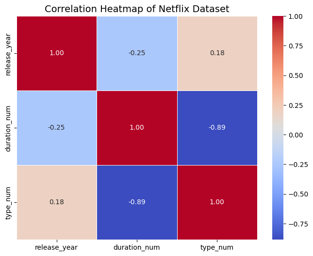

```python
# Convert duration column into numeric for checking the correlation
df['duration_num'] = df['duration'].str.extract('(\d+)').astype(float)

# Creating new feature (Movie=0, TV Show=1)
df['type_num'] = df['type'].map({'Movie': 0, 'TV Show': 1})


# Selecting the numerical columns
num_cols = df.select_dtypes(include='number').columns

# Defining the correlation
corr = df[num_cols].corr()

# Plotting the Heatmap
plt.figure(figsize=(8,6))
sns.heatmap(corr, annot=True, cmap="coolwarm", linewidths=0.5, fmt=".2f")
plt.title("Correlation Heatmap of Netflix Dataset", fontsize=14)
plt.show()
```

#### Business Question 1: How is the platform’s content divided between Movies and TV Shows, and how has that changed over the years?

```python
df['listed_in'].head(10)
```

|  | listed_in |
| --- | --- |
| 0 | [Documentaries] |
| 1 | [International TV Shows, TV Dramas, TV Mysteries] |
| 2 | [Crime TV Shows, International TV Shows, TV Ac... |
| 3 | [Docuseries, Reality TV] |
| 4 | [International TV Shows, Romantic TV Shows, TV... |
| 5 | [TV Dramas, TV Horror, TV Mysteries] |
| 6 | [Children & Family Movies] |
| 7 | [Dramas, Independent Movies, International Mov... |
| 8 | [British TV Shows, Reality TV] |
| 9 | [Comedies, Dramas] |

**dtype:** object

```python
# Counting the content types
content_counts = df['type'].value_counts()
content_counts.reset_index()
```

|  | type | count |
| --- | --- | --- |
| 0 | Movie | 6125 |
| 1 | TV Show | 2665 |

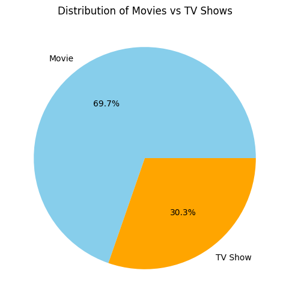

```python
# Pie chart
plt.figure(figsize=(6,6))
plt.pie(content_counts, labels=content_counts.index, autopct='%1.1f%%', colors=['skyblue', 'orange'])
plt.title('Distribution of Movies vs TV Shows')
plt.show()
```

We can see that there are two type of content (Movie, TV Show) in our dataset.  
In that out of 8,790 titles, Movies make up 6,125 (which is about ≈ 70%) and TV Show make up 2,665 (which is about ≈ 30%), Shows that Movie type is hosted majority in the platform.

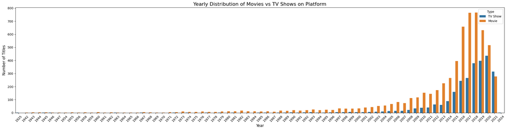

```python
# Count of content type per release year
yearly_counts = df.groupby(['release_year', 'type']).size().reset_index(name='count')


plt.figure(figsize=(23,6))
sns.barplot(data=yearly_counts, x='release_year', y='count', hue='type')
plt.title('Yearly Distribution of Movies vs TV Shows on Platform', fontsize=16)
plt.xlabel('Year', fontsize=12)
plt.ylabel('Number of Titles', fontsize=12)
plt.xticks(rotation=45)
plt.legend(title='Type')
plt.tight_layout()
plt.show()
```

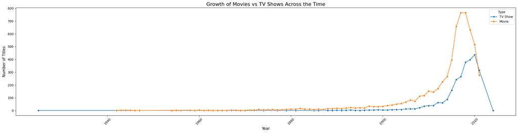

```python
plt.figure(figsize=(23,6))
sns.lineplot(data=yearly_counts, x='release_year', y='count', hue='type', marker='o')

plt.title("Growth of Movies vs TV Shows Across the Time", fontsize=16)
plt.xlabel("Year", fontsize=12)
plt.ylabel("Number of Titles", fontsize=12)
plt.xticks(rotation=45)
plt.legend(title='Type')
plt.tight_layout()
plt.show()
```

How is the platform’s content divided between Movies and TV Shows, and how has that changed over the years?

#### Business Question 2: Which countries produce the highest volume of content, and does the nature of such content differ from one country to another?

```python
df.head(10)
```

|  | type | title | country | release_year | rating | duration | listed_in | date_added_formatted | duration_num | type_num |
| --- | --- | --- | --- | --- | --- | --- | --- | --- | --- | --- |
| 0 | Movie | Dick Johnson Is Dead | United States | 2020 | PG-13 | 90 min | [Documentaries] | 2021-09-25 | 90.0 | 0 |
| 1 | TV Show | Blood & Water | South Africa | 2021 | TV-MA | 2 Seasons | [International TV Shows, TV Dramas, TV Mysteries] | 2021-09-24 | 2.0 | 1 |
| 2 | TV Show | Ganglands | India | 2021 | TV-MA | 1 Season | [Crime TV Shows, International TV Shows, TV Ac... | 2021-09-24 | 1.0 | 1 |
| 3 | TV Show | Jailbirds New Orleans | France,Qatar | 2021 | TV-MA | 1 Season | [Docuseries, Reality TV] | 2021-09-24 | 1.0 | 1 |
| 4 | TV Show | Kota Factory | India | 2021 | TV-MA | 2 Seasons | [International TV Shows, Romantic TV Shows, TV... | 2021-09-24 | 2.0 | 1 |
| 5 | TV Show | Midnight Mass | United Kingdom | 2021 | TV-MA | 1 Season | [TV Dramas, TV Horror, TV Mysteries] | 2021-09-24 | 1.0 | 1 |
| 6 | Movie | My Little Pony: A New Generation | United States | 2021 | PG | 91 min | [Children & Family Movies] | 2021-09-24 | 91.0 | 0 |
| 7 | Movie | Sankofa | United States,Ghana,Burkina Faso,United Kingdo... | 1993 | TV-MA | 125 min | [Dramas, Independent Movies, International Mov... | 2021-09-24 | 125.0 | 0 |
| 8 | TV Show | The Great British Baking Show | United Kingdom | 2021 | TV-14 | 9 Seasons | [British TV Shows, Reality TV] | 2021-09-24 | 9.0 | 1 |
| 9 | Movie | The Starling | United States | 2021 | PG-13 | 104 min | [Comedies, Dramas] | 2021-09-24 | 104.0 | 0 |

```python
top_10_country = df["country"].dropna().str.split(",").explode().str.strip().value_counts().reset_index().head(10)
top_10_country
```

|  | country | count |
| --- | --- | --- |
| 0 | United States | 4089 |
| 1 | India | 1137 |
| 2 | United Kingdom | 877 |
| 3 | Canada | 488 |
| 4 | France | 445 |
| 5 | Japan | 352 |
| 6 | Spain | 256 |
| 7 | South Korea | 254 |
| 8 | Germany | 252 |
| 9 | Mexico | 186 |

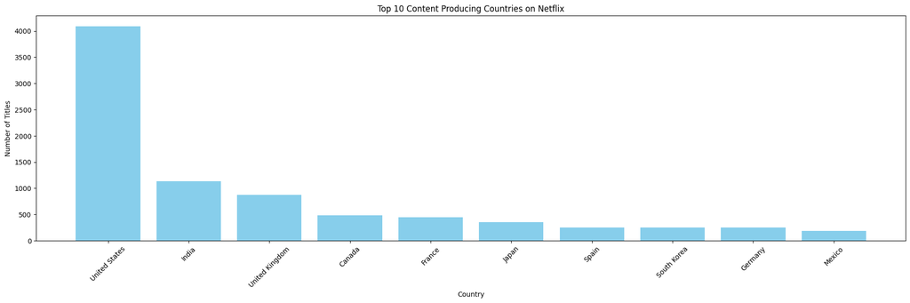

```python
# Plotting a Bar plot
plt.figure(figsize=(23,6))
plt.bar(top_10_country['country'], top_10_country['count'], color='skyblue')
plt.xticks(rotation=45)
plt.xlabel("Country")
plt.ylabel("Number of Titles")
plt.title("Top 10 Content Producing Countries on Netflix")
plt.show()
```

Insights from data and graph:

United States is the most content produced country among the other countries. Follewed by India, United Kingdom, Canada and with the rest of the countries.

```python
#Split multiple countries into separate rows
df_exploded = df.dropna(subset=['country']).copy()
df_exploded['country'] = df_exploded['country'].str.split(",")
df_exploded = df_exploded.explode('country')
df_exploded['country'] = df_exploded['country'].str.strip()  # Removing the whitespace

#Group by the country and type
type_distribution = df_exploded.groupby(['country', 'type']).size().reset_index(name='count')

#Pivot to get Movies and TV Shows in separate columns
type_distribution = type_distribution.pivot(index='country', columns='type', values='count').fillna(0)

# Step 4: Add totals and percentages
type_distribution['Total'] = type_distribution.sum(axis=1)
type_distribution['Movie %'] = round((type_distribution['Movie'] / type_distribution['Total']) * 100, 2)
type_distribution['TV Show %'] = round((type_distribution['TV Show'] / type_distribution['Total']) * 100, 2)

# Step 5: Sort by total
top_10_type_distribution = type_distribution.sort_values(by='Total', ascending=False).head(10)
top_10_type_distribution
```

| type country | Movie | TV Show | Total | Movie % | TV Show % |
| --- | --- | --- | --- | --- | --- |
| United States | 2963.0 | 1126.0 | 4089.0 | 72.46 | 27.54 |
| India | 1013.0 | 124.0 | 1137.0 | 89.09 | 10.91 |
| United Kingdom | 567.0 | 310.0 | 877.0 | 64.65 | 35.35 |
| Canada | 341.0 | 147.0 | 488.0 | 69.88 | 30.12 |
| France | 329.0 | 116.0 | 445.0 | 73.93 | 26.07 |
| Japan | 136.0 | 216.0 | 352.0 | 38.64 | 61.36 |
| Spain | 187.0 | 69.0 | 256.0 | 73.05 | 26.95 |
| South Korea | 71.0 | 183.0 | 254.0 | 27.95 | 72.05 |
| Germany | 194.0 | 58.0 | 252.0 | 76.98 | 23.02 |
| Mexico | 121.0 | 65.0 | 186.0 | 65.05 | 34.95 |

```python
#Sorting the values by Movie % column
top_10_type_distribution.sort_values(by="Movie %", ascending=False, inplace=False)
```

| type country | Movie | TV Show | Total | Movie % | TV Show % |
| --- | --- | --- | --- | --- | --- |
| India | 1013.0 | 124.0 | 1137.0 | 89.09 | 10.91 |
| Germany | 194.0 | 58.0 | 252.0 | 76.98 | 23.02 |
| France | 329.0 | 116.0 | 445.0 | 73.93 | 26.07 |
| Spain | 187.0 | 69.0 | 256.0 | 73.05 | 26.95 |
| United States | 2963.0 | 1126.0 | 4089.0 | 72.46 | 27.54 |
| Canada | 341.0 | 147.0 | 488.0 | 69.88 | 30.12 |
| Mexico | 121.0 | 65.0 | 186.0 | 65.05 | 34.95 |
| United Kingdom | 567.0 | 310.0 | 877.0 | 64.65 | 35.35 |
| Japan | 136.0 | 216.0 | 352.0 | 38.64 | 61.36 |
| South Korea | 71.0 | 183.0 | 254.0 | 27.95 | 72.05 |

As we have observed, India is producing more content from movies with 89%, comparatively to other conutry, while Germany and France is also producing a significant portion of 75% content in movies.

United States, Spain, Canada, United kingdom and Mexico is also contributing more towards Movies with a range of 63-73%.

In the contrast South Korea is contributing 70% of content towards to TV Show followed by japan witih 61% towards TV Show.

We can conclude Business Question 2:

> Which countries produce the highest volume of content?

> Does the nature of such content differ from one country to another?

-> Yes the nature of content differ from one country to another country.

-> South Korea has 70% of content in TV shows, Followed by Japan with 61% content towards the TV Show.

#### Business Question 3: Does any certain months or seasons show higher numbers of content additions on the platform?

```python
# Extracting months and seasons from date_added_formatted column
df['month'] = df['date_added_formatted'].dt.month_name()
df['month_num'] = df['date_added_formatted'].dt.month  # for ordering the months

# Defining the seasons (Northern Hemisphere assumption)
def get_season(month):
    if month in [12, 1, 2]:
        return 'Winter'
    elif month in [3, 4, 5]:
        return 'Spring'
    elif month in [6, 7, 8]:
        return 'Summer'
    else:
        return 'Autumn'

df['season'] = df['date_added_formatted'].dt.month.apply(get_season)
```

Extracting Month number and Month Name for the further analysis and we are creating new columns for Month Number and Month Name and we are creating season column for defining the season.

```python
df.head()
```

|  | type | title | country | release_year | rating | duration | listed_in | date_added_formatted | duration_num | type_num | month | month_num | season |
| --- | --- | --- | --- | --- | --- | --- | --- | --- | --- | --- | --- | --- | --- |
| 0 | Movie | Dick Johnson Is Dead | United States | 2020 | PG-13 | 90 min | [Documentaries] | 2021-09-25 | 90.0 | 0 | September | 9 | Autumn |
| 1 | TV Show | Blood & Water | South Africa | 2021 | TV-MA | 2 Seasons | [International TV Shows, TV Dramas, TV Mysteries] | 2021-09-24 | 2.0 | 1 | September | 9 | Autumn |
| 2 | TV Show | Ganglands | India | 2021 | TV-MA | 1 Season | [Crime TV Shows, International TV Shows, TV Ac... | 2021-09-24 | 1.0 | 1 | September | 9 | Autumn |
| 3 | TV Show | Jailbirds New Orleans | France,Qatar | 2021 | TV-MA | 1 Season | [Docuseries, Reality TV] | 2021-09-24 | 1.0 | 1 | September | 9 | Autumn |
| 4 | TV Show | Kota Factory | India | 2021 | TV-MA | 2 Seasons | [International TV Shows, Romantic TV Shows, TV... | 2021-09-24 | 2.0 | 1 | September | 9 | Autumn |

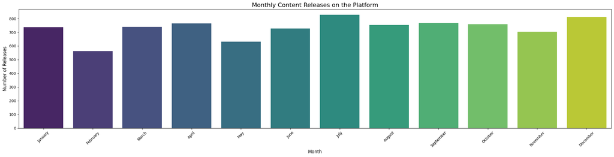

```python
monthly_counts = df.groupby(['month_num', 'month']).size().reset_index(name='count')
monthly_counts = monthly_counts.sort_values('month_num')


plt.figure(figsize=(23,6))
sns.barplot(data=monthly_counts, x='month', y='count', palette="viridis")
sns.set(style="whitegrid")
plt.title('Monthly Content Releases on the Platform', fontsize=16)
plt.xlabel('Month', fontsize=12)
plt.ylabel('Number of Releases', fontsize=12)
plt.xticks(rotation=45)
plt.tight_layout()
plt.show()
```

```python
monthly_counts.sort_values(by='count')
```

|  | month_num | month | count |
| --- | --- | --- | --- |
| 1 | 2 | February | 562 |
| 4 | 5 | May | 632 |
| 10 | 11 | November | 705 |
| 5 | 6 | June | 728 |
| 0 | 1 | January | 737 |
| 2 | 3 | March | 740 |
| 7 | 8 | August | 754 |
| 9 | 10 | October | 759 |
| 3 | 4 | April | 765 |
| 8 | 9 | September | 769 |
| 11 | 12 | December | 812 |
| 6 | 7 | July | 827 |

```python
monthly_counts['count'].mean()
```

```
np.float64(732.5)
```

Insights from the above graph:

5. From these points and graph, these indicates that summer(july & august) and winter(year-end) is the peak periods for the content additions.

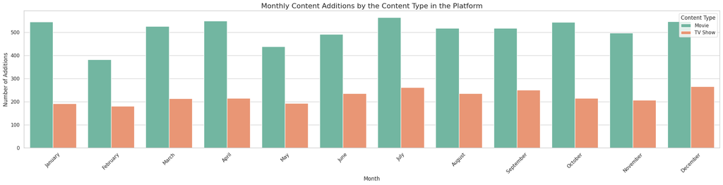

```python
monthly_counts_type = df.groupby(['month_num', 'month', 'type']).size().reset_index(name='count')
monthly_counts_type = monthly_counts_type.sort_values('month_num')


plt.figure(figsize=(23,6))
sns.barplot(data=monthly_counts_type, x='month', y='count', hue='type', palette="Set2")
sns.set(style="whitegrid")
plt.title('Monthly Content Additions by the Content Type in the Platform', fontsize=16)
plt.xlabel('Month', fontsize=12)
plt.ylabel('Number of Additions', fontsize=12)
plt.xticks(rotation=45)
plt.legend(title='Content Type')
plt.tight_layout()
plt.show()
```

```python
monthly_counts_type[monthly_counts_type['type'] == 'Movie'].sort_values(by='count')
```

|  | month_num | month | type | count |
| --- | --- | --- | --- | --- |
| 2 | 2 | February | Movie | 382 |
| 8 | 5 | May | Movie | 439 |
| 10 | 6 | June | Movie | 492 |
| 20 | 11 | November | Movie | 498 |
| 16 | 9 | September | Movie | 518 |
| 14 | 8 | August | Movie | 518 |
| 4 | 3 | March | Movie | 527 |
| 18 | 10 | October | Movie | 544 |
| 0 | 1 | January | Movie | 545 |
| 22 | 12 | December | Movie | 547 |
| 6 | 4 | April | Movie | 550 |
| 12 | 7 | July | Movie | 565 |

```python
monthly_counts_type[monthly_counts_type['type'] == 'TV Show'].sort_values(by='count')
```

|  | month_num | month | type | count |
| --- | --- | --- | --- | --- |
| 3 | 2 | February | TV Show | 180 |
| 1 | 1 | January | TV Show | 192 |
| 9 | 5 | May | TV Show | 193 |
| 21 | 11 | November | TV Show | 207 |
| 5 | 3 | March | TV Show | 213 |
| 7 | 4 | April | TV Show | 215 |
| 19 | 10 | October | TV Show | 215 |
| 11 | 6 | June | TV Show | 236 |
| 15 | 8 | August | TV Show | 236 |
| 17 | 9 | September | TV Show | 251 |
| 13 | 7 | July | TV Show | 262 |
| 23 | 12 | December | TV Show | 265 |

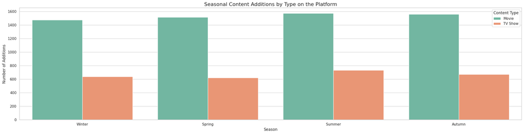

```python
season_counts_type = df.groupby(['season', 'type']).size().reset_index(name='count')

# Ordering the seasons
season_order = ['Winter','Spring','Summer','Autumn']
season_counts_type['season'] = pd.Categorical(season_counts_type['season'], categories=season_order, ordered=True)
season_counts_type = season_counts_type.sort_values('season')


sns.set(style="whitegrid")
plt.figure(figsize=(23,6))
sns.barplot(data=season_counts_type, x='season', y='count', hue='type', palette="Set2")
plt.title('Seasonal Content Additions by Type on the Platform', fontsize=16)
plt.xlabel('Season', fontsize=12)
plt.ylabel('Number of Additions', fontsize=12)
plt.legend(title='Content Type')
plt.tight_layout()
plt.show()
```

```python
season_counts_type.groupby('season')['count'].agg('sum').reset_index().sort_values(by='count', ascending=False)
```

|  | season | count |
| --- | --- | --- |
| 2 | Summer | 2309 |
| 3 | Autumn | 2233 |
| 1 | Spring | 2137 |
| 0 | Winter | 2111 |

Concluding Business Question 3:

**Does any certain months or seasons show higher numbers of content additions on the platform?**

**Peak Months:** July with highest number of additions of 827.

**Peak Seasons:** Summer (June–August) has 2309 additions and Autumn (September–November) has 2233 additions.

Overall Movies is consistently dominate in content additions and TV Show also follows the similar trend as Movies.

```python
# Creating a copy of the dataset
df_country_rating = df
```

```python
# Spliting countries into separate rows
df_country_rating = df_country_rating.assign(
    country=df_country_rating['country'].str.split(',')
).explode('country')

# Remove extra spaces from the country column
df_country_rating['country'] = df_country_rating['country'].str.strip()
```

```python
rating_counts = df_country_rating.groupby(['country', 'rating']).size().reset_index(name='count')
```

```python
# Top 10 countries by rating volume
top_countries = df_country_rating['country'].value_counts().head(10).index

rating_counts_top = rating_counts[rating_counts['country'].isin(top_countries)]
```

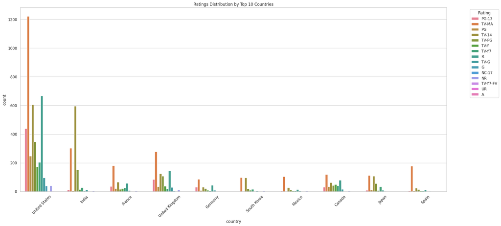

```python
plt.figure(figsize=(23,10))
sns.countplot(data=df_country_rating[df_country_rating['country'].isin(top_countries)],
              x='country', hue='rating')
plt.title("Ratings Distribution by Top 10 Countries")
plt.xticks(rotation=45)
plt.legend(title="Rating", bbox_to_anchor=(1.05, 1), loc='upper left')
plt.show()
```

Insights from the graph:

[output not shown]

Yes, countries typically generate content with specific ratings indeed.

[output not shown]

#### Business Question 5: What genres stand out as the most popular, and how common is it for a show or a movie to be classified under several genres?

```python
# Count number of genres per show/movie
df['num_genres'] = df['listed_in'].apply(len)

# Explode for individual genre analysis
df_exploded = df.explode('listed_in')
df_exploded['listed_in'] = df_exploded['listed_in'].str.strip()
```

```python
df.head()
```

|  | type | title | country | release_year | rating | duration | listed_in | date_added_formatted | duration_num | type_num | month | month_num | season | num_genres |
| --- | --- | --- | --- | --- | --- | --- | --- | --- | --- | --- | --- | --- | --- | --- |
| 0 | Movie | Dick Johnson Is Dead | United States | 2020 | PG-13 | 90 min | [Documentaries] | 2021-09-25 | 90.0 | 0 | September | 9 | Autumn | 1 |
| 1 | TV Show | Blood & Water | South Africa | 2021 | TV-MA | 2 Seasons | [International TV Shows, TV Dramas, TV Mysteries] | 2021-09-24 | 2.0 | 1 | September | 9 | Autumn | 3 |
| 2 | TV Show | Ganglands | India | 2021 | TV-MA | 1 Season | [Crime TV Shows, International TV Shows, TV Ac... | 2021-09-24 | 1.0 | 1 | September | 9 | Autumn | 3 |
| 3 | TV Show | Jailbirds New Orleans | France,Qatar | 2021 | TV-MA | 1 Season | [Docuseries, Reality TV] | 2021-09-24 | 1.0 | 1 | September | 9 | Autumn | 2 |
| 4 | TV Show | Kota Factory | India | 2021 | TV-MA | 2 Seasons | [International TV Shows, Romantic TV Shows, TV... | 2021-09-24 | 2.0 | 1 | September | 9 | Autumn | 3 |

```python
# Count how many shows/movies belong to each genre
genre_counts = df_exploded['listed_in'].value_counts().reset_index()
genre_counts.columns = ['genre', 'count']

# Display top 10 genres
genre_counts.head(10)
```

|  | genre | count |
| --- | --- | --- |
| 0 | International Movies | 2752 |
| 1 | Dramas | 2424 |
| 2 | Comedies | 1673 |
| 3 | International TV Shows | 1349 |
| 4 | Documentaries | 869 |
| 5 | Action & Adventure | 859 |
| 6 | TV Dramas | 762 |
| 7 | Independent Movies | 755 |
| 8 | Children & Family Movies | 641 |
| 9 | Romantic Movies | 616 |

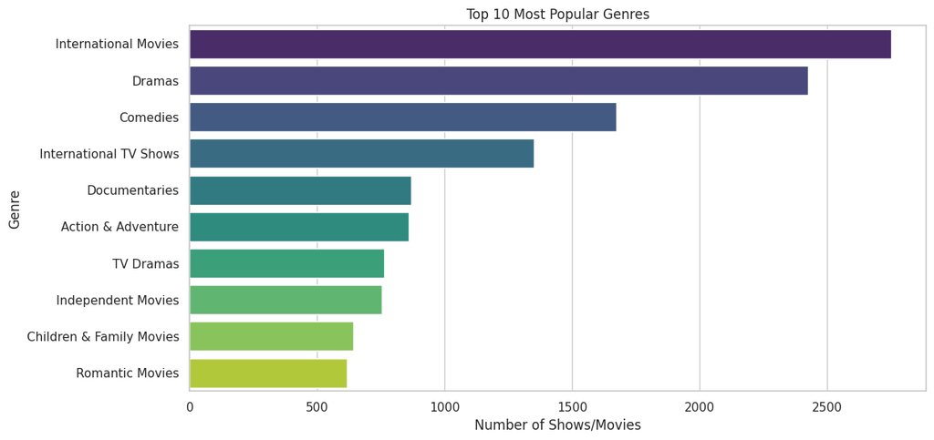

```python
plt.figure(figsize=(12,6))
sns.barplot(data=genre_counts.head(10), x='count', y='genre', palette='viridis')
plt.title("Top 10 Most Popular Genres")
plt.xlabel("Number of Shows/Movies")
plt.ylabel("Genre")
plt.show()
```

Insights from the above graph and data:

The most popular genres are internationl movies has about(2752 titles), dramas with (2424 titles), and comedies with (1673 titles), these is the dominant categories in the catalog.

Together they represent the majority of the available content, with strong audience interest towards these generes.

```python
# Count frequency of number of genres per show/movie
genre_frequency = df['num_genres'].value_counts().reset_index()
genre_frequency.columns = ['num_genres', 'count']

# Display distribution
print(genre_frequency)
```

```
   num_genres  count
0           3   3727
1           2   3051
2           1   2012
```

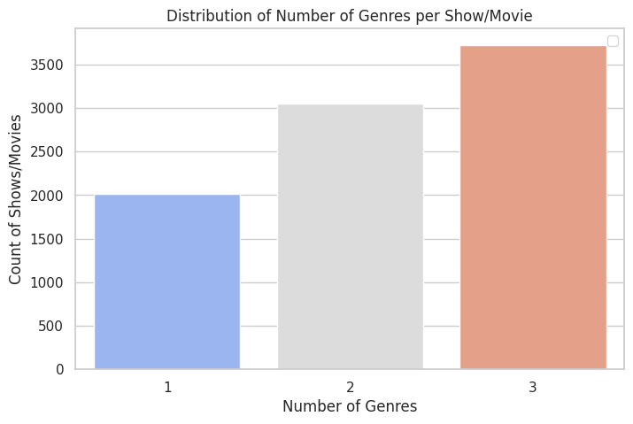

```python
plt.figure(figsize=(8,5))
sns.countplot(data=df, x='num_genres', palette='coolwarm')
plt.title("Distribution of Number of Genres per Show/Movie")
plt.xlabel("Number of Genres")
plt.ylabel("Count of Shows/Movies")
plt.legend()
plt.show()
```

Insights from above graph and data:

It is very common for a title to be classified under multiple genres which is over 75% of the shows and movies falling into 2-3 genres, while about only 20 % titles belong to a single genre.

Multi-genre classification being the general case allows content to be operly marketed along with appealing to wider audience preferences."

Concluding Business Question 5:

**What genres stand out as the most popular?**

The most popular genres are internationl movies has about(2752 titles), dramas with (2424 titles), and comedies with (1673 titles), these is the dominant categories in the catalog.

**how common is it for a show or a movie to be classified under several genres?**

These indicated that multi-genre classification is the standard way, As Multi-genre classification being the general case allows content to be operly marketed along with appealing to wider audience preferences.

#### Conculsion

This analysis of the Netflix Movies and TV Shows dataset, has highlighted the several important key insights into the platform’s content strategy and audience engagement:

1. Content Type trends : From the 1980's movies have been the majority of netflix collection. growing rapidly and reaching it's peak in the year 2018. However TV Show have also grown significantly in the early 2000's. and reached it's peak in the year 2020.
2. National Contribution : United States is the largest content contributors. among the rest of the country by following with India, United Kingdom, Cannada are the next largest content contributors.

While South Korea and japan country's prefer more towards towards, TV Show than Movies and India, Germany, France have more preference's towards Movies.

This shows us that netflix adapts its various type of collection to different markets and stages of development.

Additionally most of the titles fall under multiple genres. suggesting that this can be a fundamental tactic to increase number of popularity and attract a wider range of audience segments.

Overall, Netflix’s Expansion has been supported by a solid film base, with TV Shows playing a bigger role in the recent years. content rating alignment, seasonal release strategies, and regional diversity of the platform all this shows an organized strategy to maximize the reach and engagement across the various markets.